# report_estimation_costs_parameter

Daisy Dan Song

2025-05-14

# import estimation equilibrium

# Clarify the issues

## Use approximate method

### without updating demand shocks

#### ths with negative costs

```
##    max_cost_f max_cost_w t  j i
## 1  -8.6213574  0.7979531 1  2 2
## 2 -10.1950864  2.9534065 1 12 2
## 3 -35.6183016  0.8182757 1 14 2
## 4  -9.4826459  0.2797287 1 15 2
## 5  -0.6584761  0.6047305 1 24 2
## 6 -64.1069871  0.7025869 1 30 2
```

### with updating demand shocks

#### ths with negative costs

```
##   max_cost_f max_cost_w t j i
## 1 -0.2359647  0.7769663 1 3 2
## 2 -0.5522016 18.0631205 1 5 2
## 3 -2.3767862 16.8760657 1 8 3
## 4 -1.0284965  0.6791529 1 8 4
## 5 -1.6817955  2.3102408 1 8 5
## 6 -5.3293937  1.8274531 1 8 6
```

- In the estimation, we cannot find the parameters that make some costs positive for any lambda_w and lambda_f.
  - How many markets show this problem?
    - Without updating demand shocks, only 1 market out of 500 for c_w, 109 market out of 500 for c_f
    - With updating demand shocks, 0 market out of 500 for c_w, 324 market out of 500 for c_f
  - How many ths show this problem?
    - Without updating demand shocks, only 2 ths out of 988 for c_w, 129 ths out of 988 for c_f
    - With updating demand shocks, 0 ths out of 988 for c_w, 656 ths out of 988 for c_f

## Use exact method

- delete large markets

### without updating demand shocks

#### ths with negative costs

```
##      max_cost_f    max_cost_w t  j i
## 1 -8.624561e+00   0.242029160 1  2 2
## 2  1.168246e+10  -0.006298377 1  5 2
## 3  1.463855e+14 -29.152021459 1  7 2
## 4  2.417038e+13  -0.072564456 1  9 3
## 5  8.538337e+13  -0.001231956 1  9 4
## 6 -1.045132e+01   0.020857735 1 12 2
```

### with updating demand shocks

#### ths with negative costs

```
##     max_cost_f   max_cost_w t  j i
## 1 1.166251e+05  -8.91629581 1  7 2
## 2 4.589038e+01  -0.15803519 1 13 2
## 3 3.571708e+01  -0.23884503 1 18 2
## 4 2.238527e+04 -12.24654319 1 20 2
## 5 4.995241e+00  -0.02290068 1 21 2
## 6 1.156339e+04  -4.85786626 1 26 2
```

- In the estimation, we cannot find the parameters that make some costs positive for any lambda_w and lambda_f
  - How many markets show this problem?
    - Without updating demand shocks, only 97 market out of 458 for c_w, 88 market out of 458 for c_f
    - With updating demand shocks, 81 market out of 458 for c_w, 0 market out of 458 for c_f
  - How many ths show this problem?
    - Without updating demand shocks, only 102 ths out of 566 for c_w, 95 ths out of 566 for c_f
    - With updating demand shocks, 87 ths out of 566 for c_w, 0 ths out of 566 for c_f

# Make $m_w + m_f = 1.5 > 1$

## Use approximate method

### without updating demand shocks

#### ths with negative costs

```
##     max_cost_f  max_cost_w t j  i
## 1 8.195174e+10 -0.05940501 1 3  2
## 2 4.286298e+14 -3.42095558 1 8  4
## 3 2.292823e+15 -0.08783996 1 8  6
## 4 1.886085e+15 -0.85581298 1 8  8
## 5 2.343576e+13 -4.62107195 1 8  9
## 6 2.278560e+13 -1.52207497 1 8 11
```

### with updating demand shocks

#### ths with negative costs

```
##     max_cost_f max_cost_w t j i
## 1  -102.958316  0.6376163 1 1 2
## 2 -6167.720056  4.3826011 1 1 3
## 3    -2.453833  0.2848867 1 3 2
## 4   -11.316976  2.7318514 1 5 2
## 5    -5.991453  0.5221815 1 6 2
## 6  -172.400206  1.2359230 1 8 3
```

- In the estimation, we cannot find the parameters that make some costs positive for any lambda_w and lambda_f.
  - How many markets show this problem?
    - Without updating demand shocks, only 61 market out of 500 for c_w, 1 market out of 500 for c_f
    - With updating demand shocks, 4 market out of 500 for c_w, 310 market out of 500 for c_f
  - How many ths show this problem?
    - Without updating demand shocks, only 245 ths out of 988 for c_w, 1 ths out of 988 for c_f
    - With updating demand shocks, 14 ths out of 988 for c_w, 441 ths out of 988 for c_f

## Use exact method

- delete large markets

### without updating demand shocks

#### ths with negative costs

```
##     max_cost_f  max_cost_w t  j i
## 1 2.655442e+14  -0.2005215 1  4 2
## 2 9.763951e+13  -3.5986198 1  7 2
## 3 8.544052e+14 -30.6387900 1 21 2
## 4 3.548207e+05 -30.8379403 1 28 2
## 5 1.847387e+05  -6.6731335 1 36 2
## 6 5.230571e+13  -0.5754352 1 37 2
```

### with updating demand shocks

#### ths with negative costs

```
##    max_cost_f max_cost_w t  j i
## 1 -1786.75361  0.9579255 1  3 2
## 2  -264.95347  4.1480224 1  8 3
## 3  -672.52054  5.9969791 1  8 4
## 4 -9230.92665  4.4868189 1 10 3
## 5 -2113.39173  3.2887846 1 13 2
## 6   -54.49152  0.5096722 1 14 2
```

- In the estimation, we cannot find the parameters that make some costs positive for any lambda_w and lambda_f
  - How many markets show this problem?
    - Without updating demand shocks, only 43 market out of 458 for c_w, 10 market out of 458 for c_f
    - With updating demand shocks, 1 market out of 458 for c_w, 76 market out of 458 for c_f
  - How many ths show this problem?
    - Without updating demand shocks, only 45 ths out of 566 for c_w, 10 ths out of 566 for c_f
    - With updating demand shocks, 1 ths out of 566 for c_w, 125 ths out of 566 for c_f

# Check each component

- Use exact method and update demand shocks.

# m_f + m_w = 1

- Pick up normal ths in normal markets (i.e., $c_i^W > 0$ and $c_i^F > 0$ for all $i$ in the market)
  - t = 1, j = 1
- Make two graphs:
  - Change $\lambda_w$
    - In the y-axis of the same graph, overlay the lines of
    - $c_i^W$
    - $- \frac{s_i^W(\boldsymbol w, \boldsymbol f)}{\frac{\partial s_i^W}{\partial w_i}}$
    - $f_i - w_i$.
  - Change $\lambda_f$
    - $c_i^F$
    - term 1: $\frac{q_i(\boldsymbol f) s_i^W(\boldsymbol w, \boldsymbol f)}{S^F \frac{\partial s_i^F (\boldsymbol f )}{\partial f_i}}$
    - term 2: $\frac{q_i(\boldsymbol f) \frac{\partial s_i^W(\boldsymbol w, \boldsymbol f)}{\partial f_i}}{S^F \frac{\partial s_i^F (\boldsymbol f )}{\partial f_i}}(f_i - w_i - c_i^W)$
    - term 3:$\frac{\frac{\partial q_i(\boldsymbol f)}{\partial f_i}}{S^F \frac{\partial s_i^F (\boldsymbol f )}{\partial f_i}} s_i^W(\boldsymbol w, \boldsymbol f) (f_i - w_i - c_i^W)$

## normal market

### normal ths 1

#### lambda_w

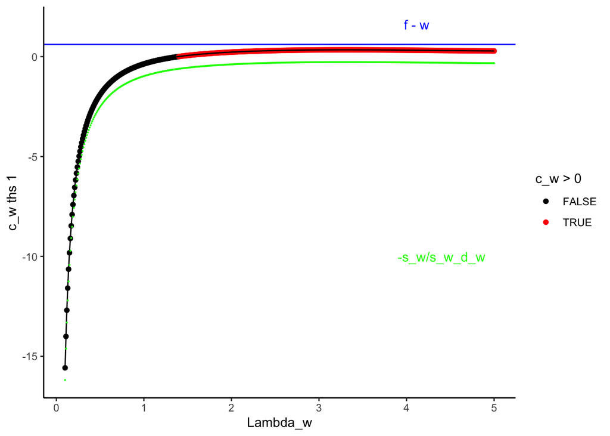

#### lambda_f

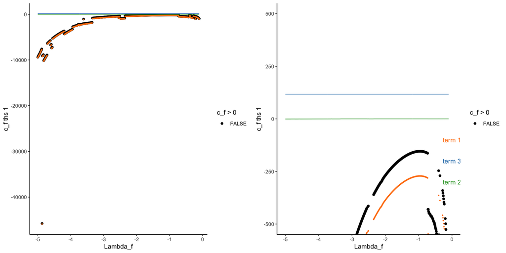

### normal ths 2

#### lambda_w

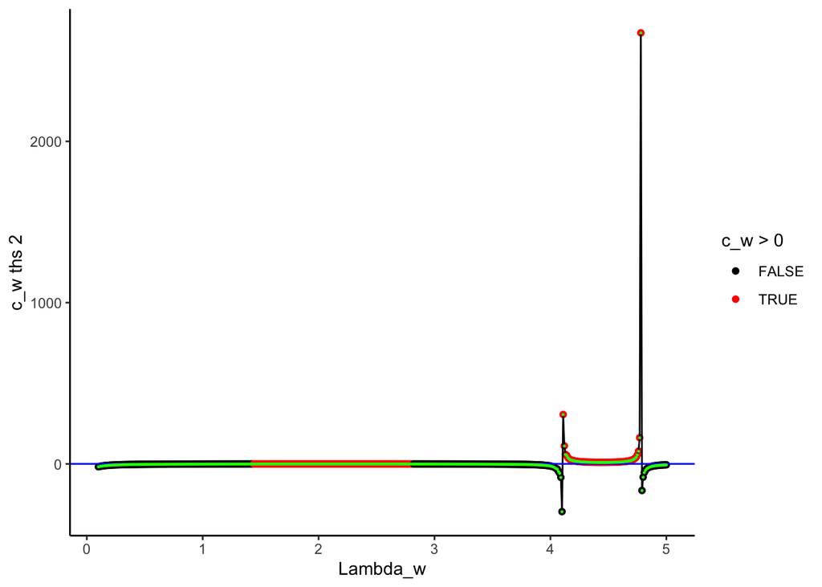

#### lambda_f

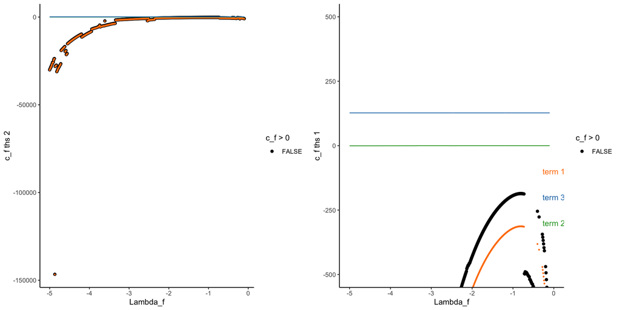

- Pick up a problematic ths in a problematic market (i.e., $c_i^W < 0$ or $c_i^F < 0$ for $i$ in the market)
  - t = 1, j = 7, i = 2

## problematic ths

### lambda_w

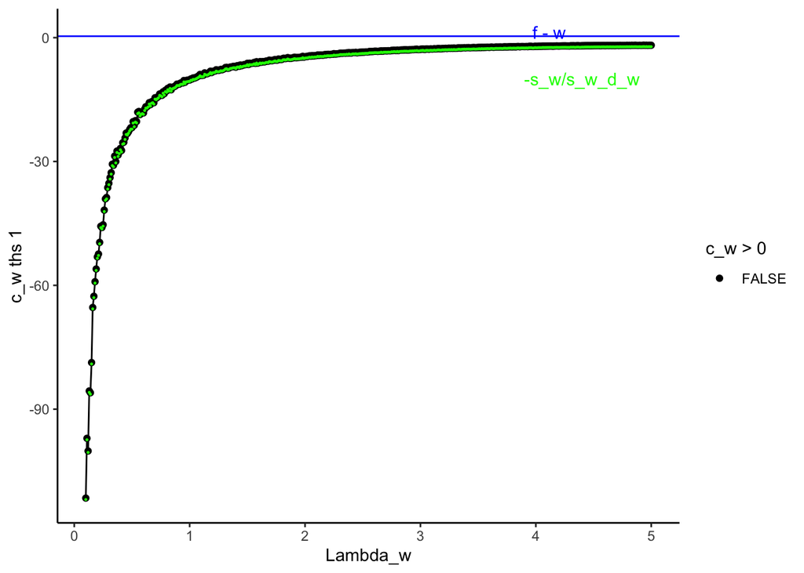

### lambda_f

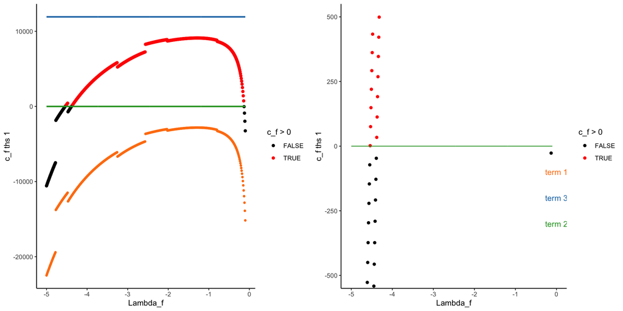

# m_f + m_w = 1.5

- Use exact method and update demand shocks.
- pick normal market t = 1, j = 1

### normal ths 1

#### lambda_w

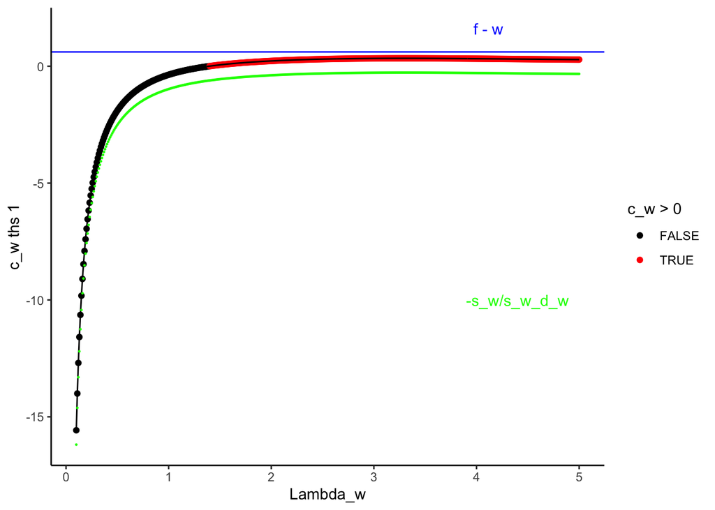

#### lambda_f

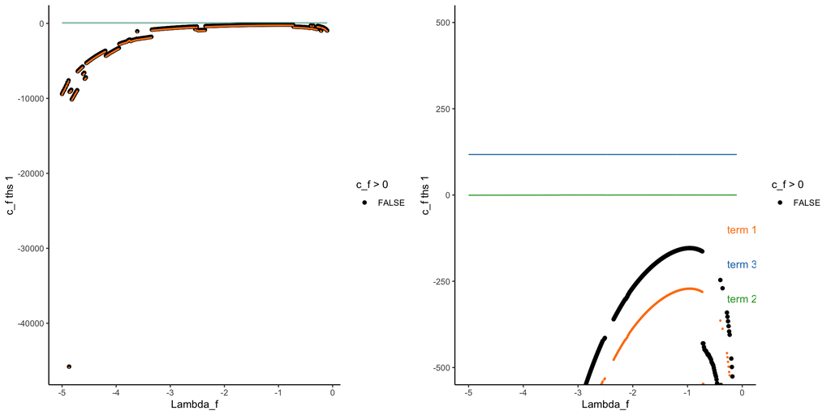

### normal ths 2

#### lambda_w

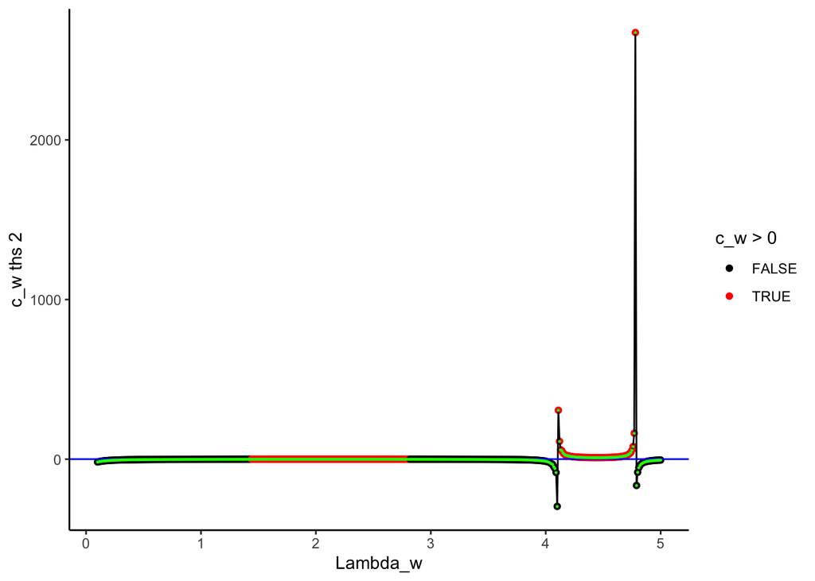

#### lambda_f

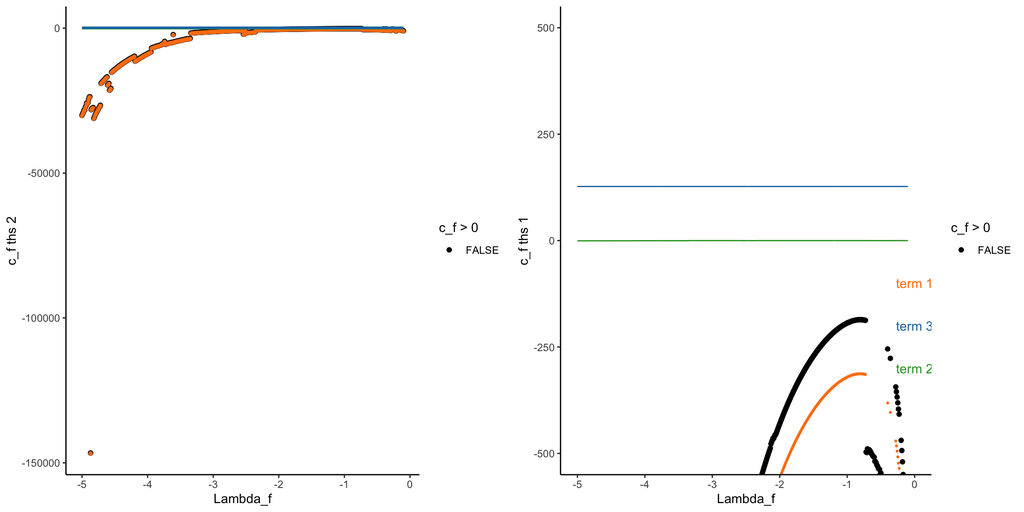

- Pick up a problematic ths in a problematic market (i.e., $c_i^W < 0$ or $c_i^F < 0$ for $i$ in the market) - t = 1, j = 3, i = 2

## problematic ths

#### lambda_w

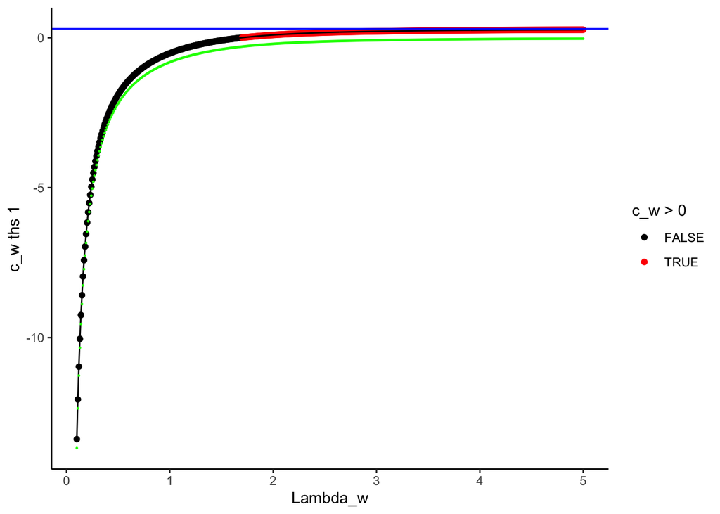

#### lambda_f

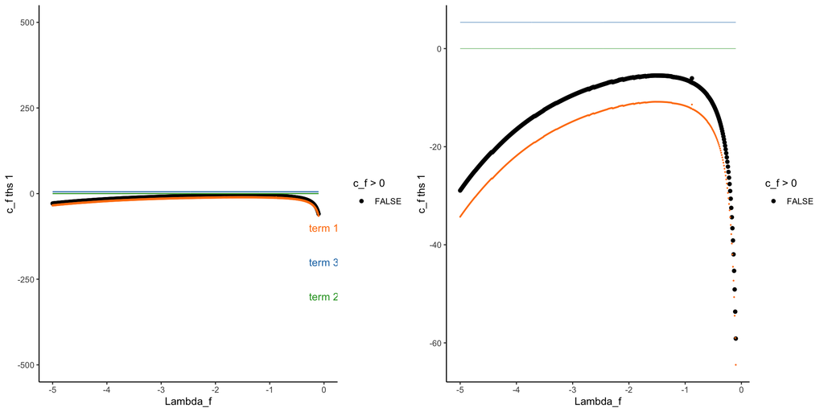

# Why $\frac{\partial s_i^W}{\partial w_i}$ is not monotone in $\lambda_w$?

- From the above graph, pick up the point before and after the jump in $\frac{\partial s_i^W}{\partial w_i}$.
- Check why this is so different.

## normal market

### normal ths 1

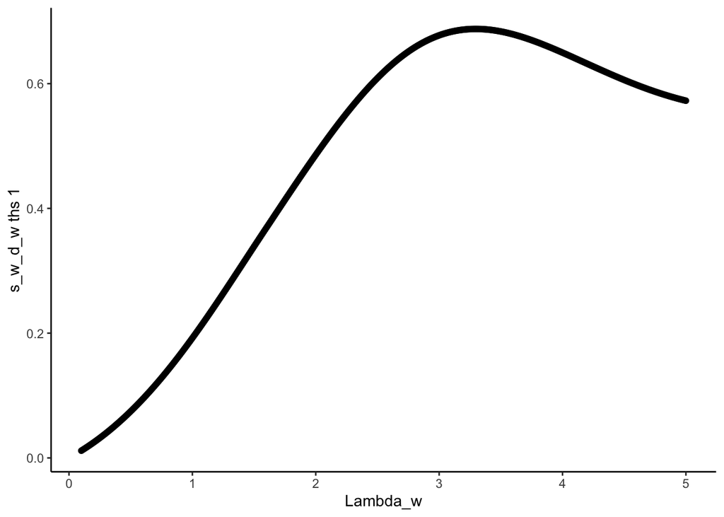

### normal ths 2

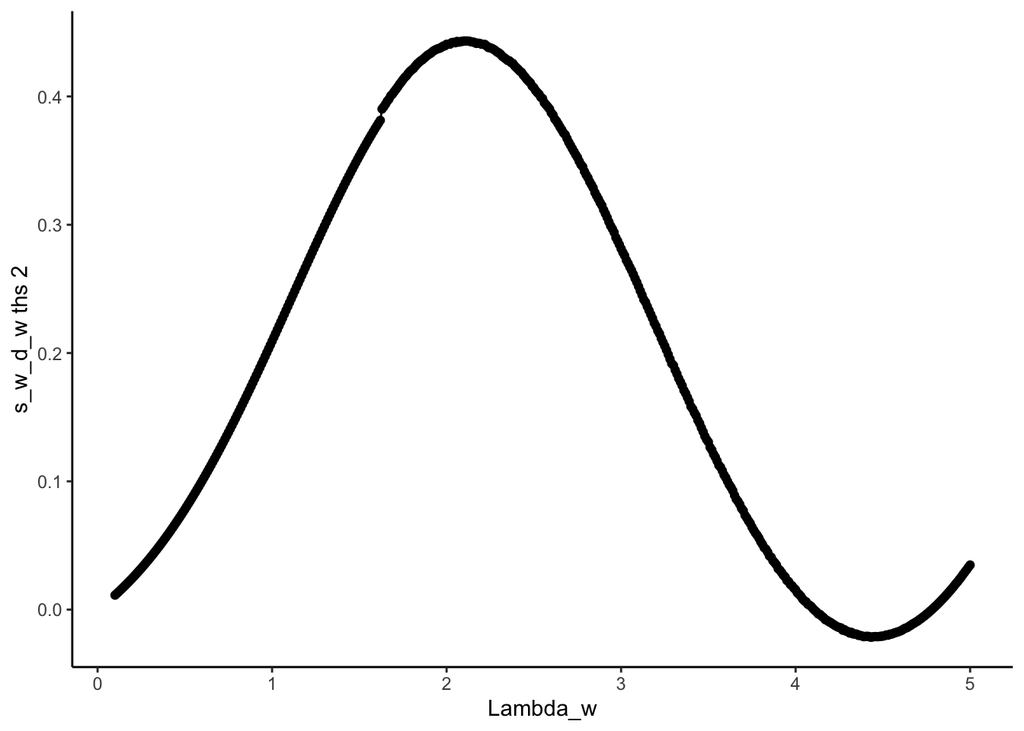

## problematic ths

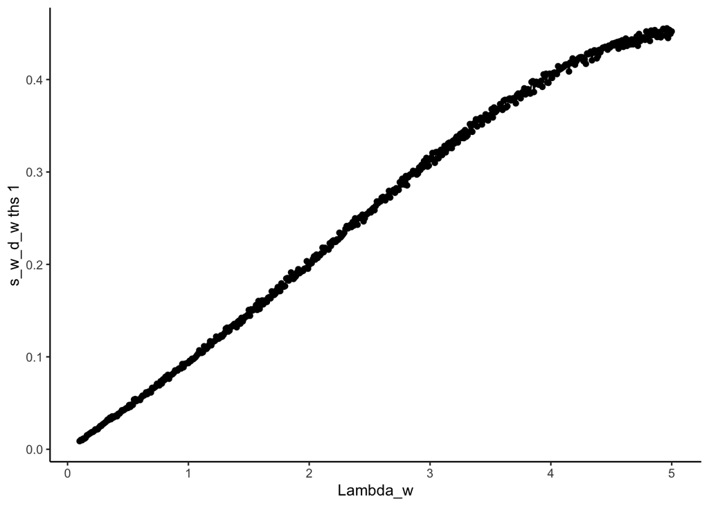